# Untitled

Yihao Li(yl4326)

2020/1/16

## Basic Graphing

```r
library(ucidata)
library(tidyverse)
library(nullabor)
library(dplyr)
```

Use one of the numeric variables in the `abalone` dataset.

```r
head(abalone)
```

```
##   sex length diameter height whole_weight shucked_weight viscera_weight
## 1   M  0.455    0.365  0.095       0.5140         0.2245         0.1010
## 2   M  0.350    0.265  0.090       0.2255         0.0995         0.0485
## 3   F  0.530    0.420  0.135       0.6770         0.2565         0.1415
## 4   M  0.440    0.365  0.125       0.5160         0.2155         0.1140
## 5   I  0.330    0.255  0.080       0.2050         0.0895         0.0395
## 6   I  0.425    0.300  0.095       0.3515         0.1410         0.0775
##   shell_weight rings
## 1        0.150    15
## 2        0.070     7
## 3        0.210     9
## 4        0.155    10
## 5        0.055     7
## 6        0.120     8
```

# traditional histogram, for continuous value, aes(variable), remember to define bins = or binwidth =

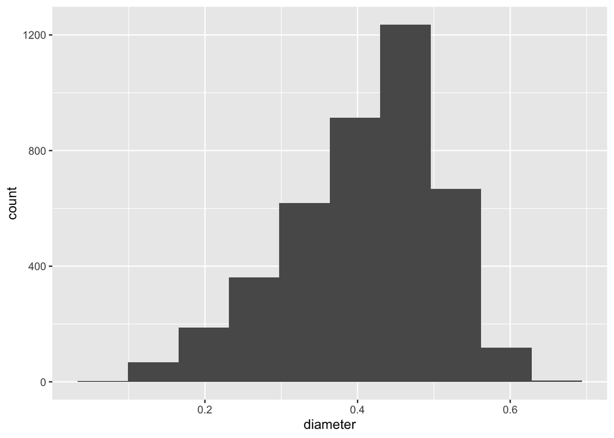

```r
ggplot(abalone, aes(diameter))+
  geom_histogram(bins = 10)
```

# facet by another variable

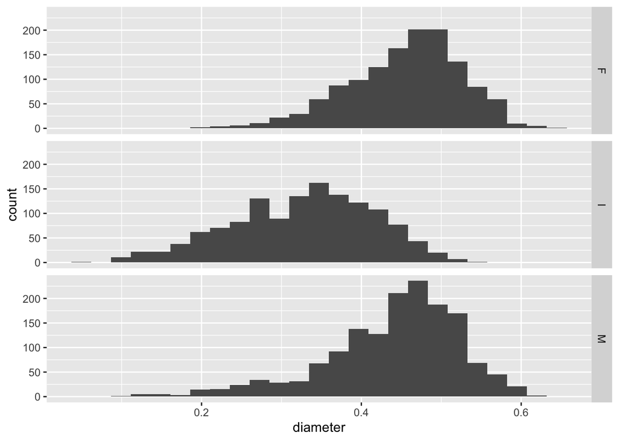

```r
ggplot(abalone, aes(diameter)) +
  geom_histogram(bins = 25) +
  facet_grid("sex")
```

Plot multiple boxplots, grouped by `sex` for the same variable. The boxplots should be ordered by decreasing median from left to right.

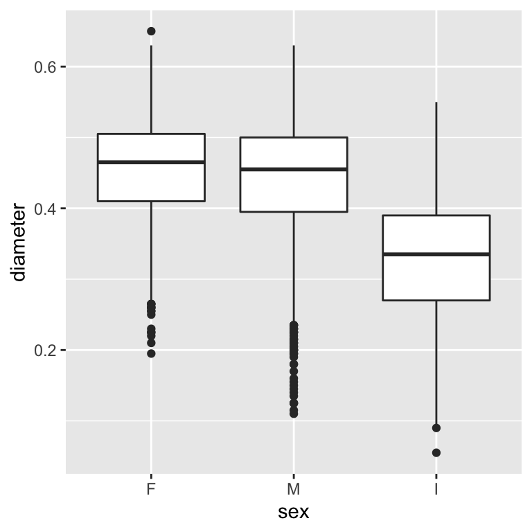

```r
library(forcats)
ggplot(abalone, aes(x = fct_reorder(sex, diameter, median, .desc = TRUE), y = diameter))+
  geom_boxplot()+
  xlab("sex")
```

Plot overlapping density curves of the same variable, one curve per factor level of `sex`, on a single set of axes. Each curve should be a different color.

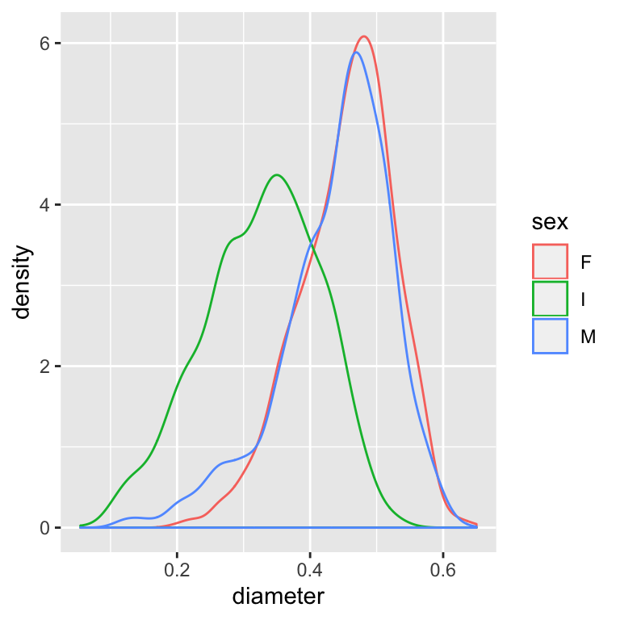

```r
ggplot(abalone, aes(diameter))+
  geom_density(aes(color=sex))
```

1. Use `tidyr::gather()` to convert the numeric columns in the `glass` dataset in the **ucidata** package to two columns: `variable` and `value`. The first few rows should be:

```
  variable   value
1       RI 1.52101
2       RI 1.51761
3       RI 1.51618
4       RI 1.51766
5       RI 1.51742
6       RI 1.51596
```

```r
glass
```

```
##      ID      RI    Na   Mg   Al    Si    K    Ca   Ba   Fe
## 1     1 1.52101 13.64 4.49 1.10 71.78 0.06  8.75 0.00 0.00
## 2     2 1.51761 13.89 3.60 1.36 72.73 0.48  7.83 0.00 0.00
## 3     3 1.51618 13.53 3.55 1.54 72.99 0.39  7.78 0.00 0.00
## 4     4 1.51766 13.21 3.69 1.29 72.61 0.57  8.22 0.00 0.00
## 5     5 1.51742 13.27 3.62 1.24 73.08 0.55  8.07 0.00 0.00
## 6     6 1.51596 12.79 3.61 1.62 72.97 0.64  8.07 0.00 0.26
## 7     7 1.51743 13.30 3.60 1.14 73.09 0.58  8.17 0.00 0.00
## 8     8 1.51756 13.15 3.61 1.05 73.24 0.57  8.24 0.00 0.00
## 9     9 1.51918 14.04 3.58 1.37 72.08 0.56  8.30 0.00 0.00
## 10   10 1.51755 13.00 3.60 1.36 72.99 0.57  8.40 0.00 0.11
## 11   11 1.51571 12.72 3.46 1.56 73.20 0.67  8.09 0.00 0.24
## 12   12 1.51763 12.80 3.66 1.27 73.01 0.60  8.56 0.00 0.00
## 13   13 1.51589 12.88 3.43 1.40 73.28 0.69  8.05 0.00 0.24
## 14   14 1.51748 12.86 3.56 1.27 73.21 0.54  8.38 0.00 0.17
```

[output cut: 415 more lines]

`glass` have the first column removed, select_if it is numeric, gather with category type column `variable` and value column named `value`

```r
gatherglass = glass[-1] %>% dplyr::select_if(., is.numeric, ) %>% tidyr::gather(key = "variable", value = "value")
head(gatherglass)
```

```
##   variable   value
## 1       RI 1.52101
## 2       RI 1.51761
## 3       RI 1.51618
## 4       RI 1.51766
## 5       RI 1.51742
## 6       RI 1.51596
```

Use this form to plot histograms of all of the variables in one plot by faceting on `variable`.

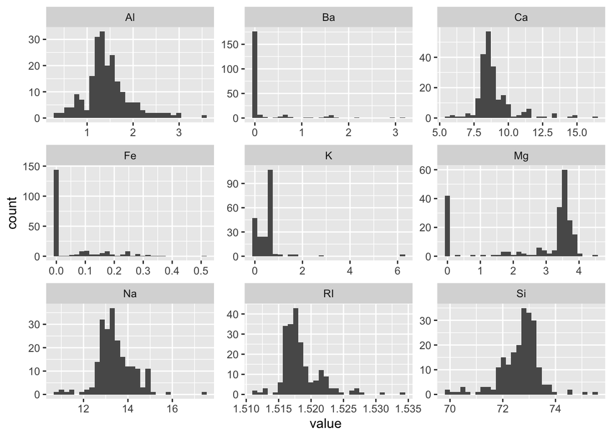

```r
ggplot(gatherglass, aes(value))+
  geom_histogram()+
  facet_wrap("variable", scales = "free")
```

# Unimodal type check normal

1. Draw a normal curve with same mean and std.deviation

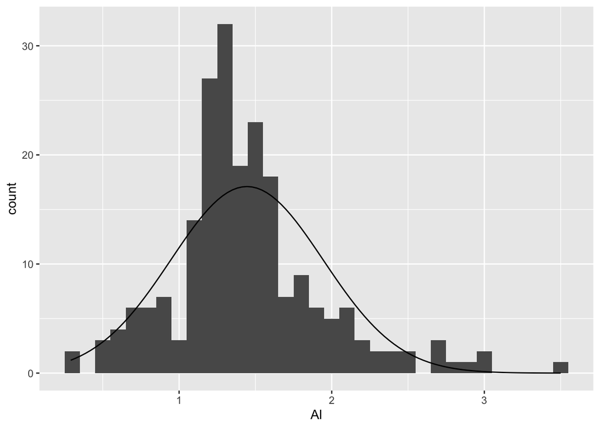

```r
ggplot(glass, aes(Al))+
  geom_histogram(binwidth = 0.1)+
  stat_function(fun = function(x, mean, sd, n,bw){
      dnorm(x = x, mean = mean, sd = sd) * n * bw
    },
    args = c(mean = mean(glass$Al), sd = sd(glass$Al), n=nrow(glass), bw = 0.1))
```

2. Shapiro-Wilk test

```r
shapiro.test(glass$Al)
```

```
##
##  Shapiro-Wilk normality test
##
## data:  glass$Al
## W = 0.94341, p-value = 2.083e-07
```

3. Draw a quantile-quantile (QQ) plot of the variable.

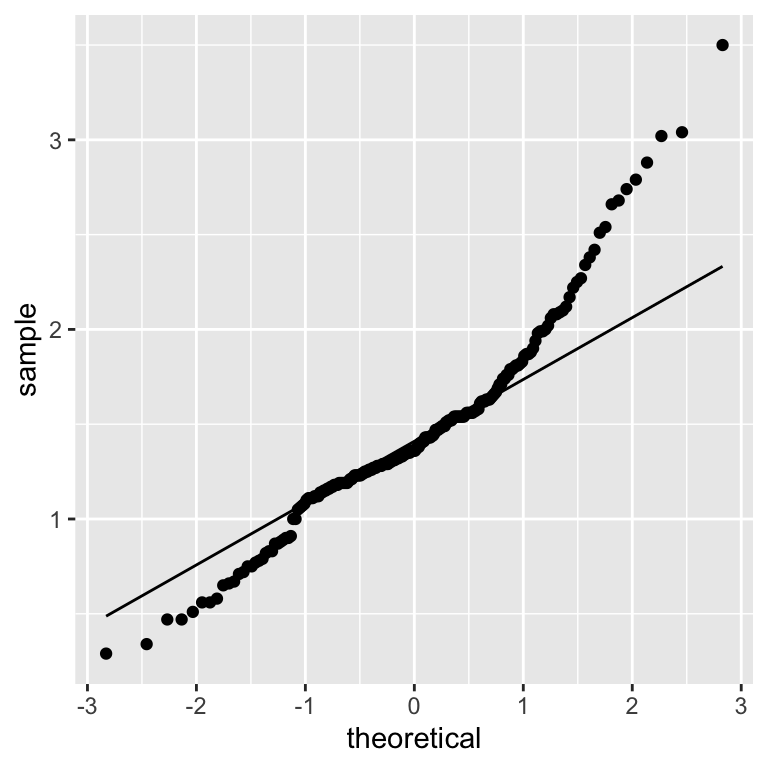

```r
ggplot(glass, aes(sample = Al)) +
  geom_qq() +
  geom_qq_line()
```

Use the **nullabor** package to create a lineup of histograms in which one panel is the real data and the others are fake data generated from a null hypothesis of normality. Can you pick out the real data? If so, how does the shape of its histogram differ from the others?

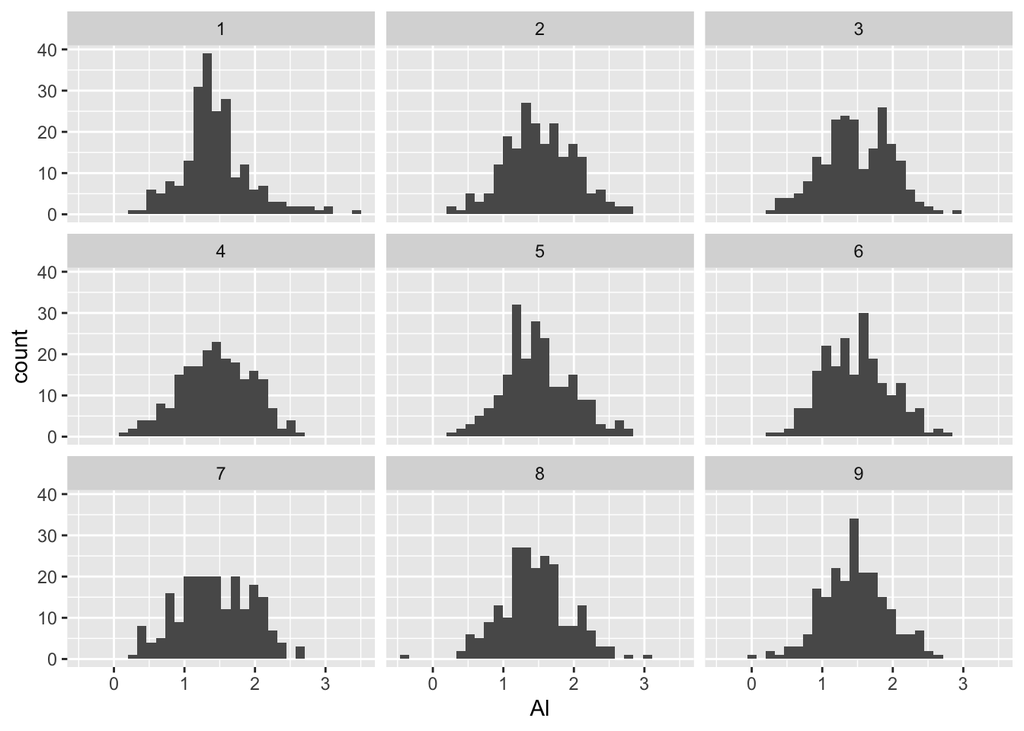

```r
al <- glass[c("Al")]
ggplot(lineup(null_dist("Al", "norm"), true = al, pos = 1, n = 9), aes(Al)) +
  geom_histogram() +
  facet_wrap (~.sample)
```

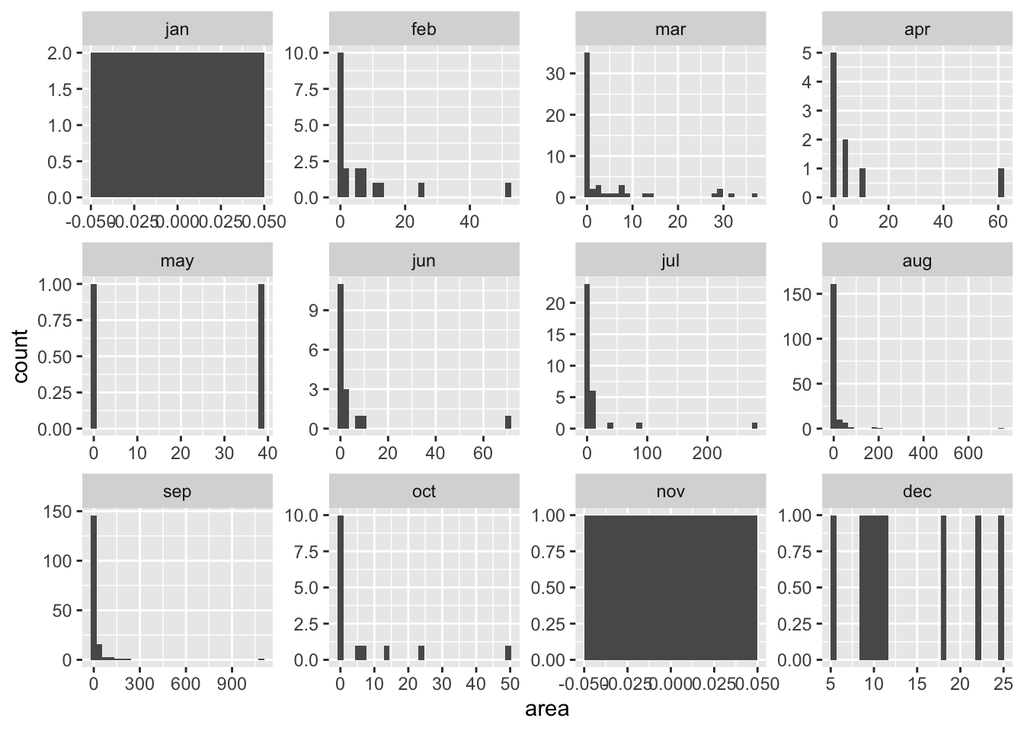

```r
fire = forest_fires[c("month", "area", "rain", "wind", "temp")]
fire$month <- factor(fire$month, levels = c("jan","feb","mar","apr","may","jun","jul","aug","sep","oct", "nov", "dec"))
ggplot(fire, aes(area)) +
  geom_histogram() +
  facet_wrap(~month, scale = "free")
```

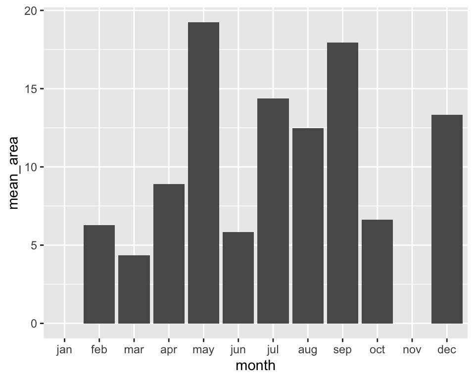

```r
average <- fire %>% group_by(month) %>% summarize (mean_area = mean(area), mean_temp = mean(temp), mean_wind = mean(wind), mean_rain = mean(rain))
ggplot(average, aes(x = month, y = mean_area)) +
  geom_col()
```

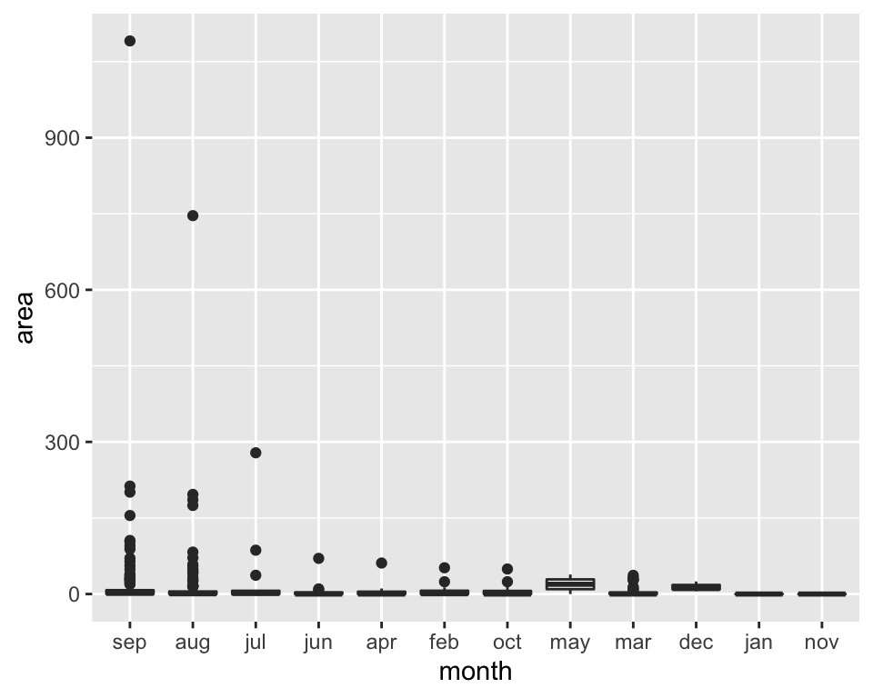

```r
ggplot(fire, aes(x = fct_reorder(month, area, max, .desc = TRUE), y = area))+
  geom_boxplot()+
  xlab("month")
```

# Horizontal Barchart

1. Create a horizontal bar chart of the responses to Q20.

```r
data = forwards::useR2016

q20_freq <- data %>%
  group_by(Q20) %>%
  summarise(freq = n()) %>%
  mutate(Q20 = ifelse(is.na(Q20), "NA", as.character(Q20)))
```

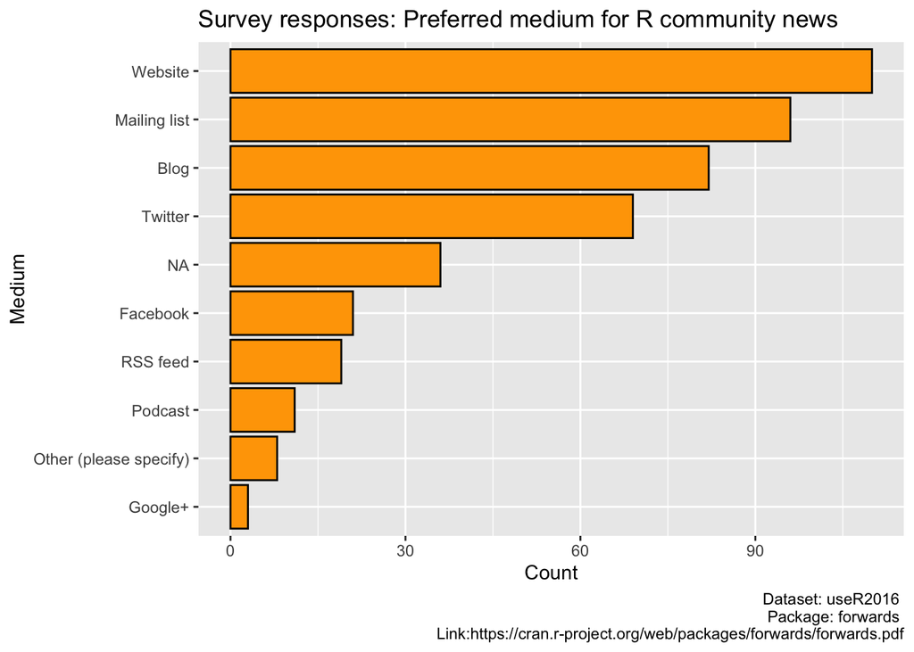

```r
ggplot(q20_freq, aes(x=fct_reorder(.f=Q20, .x=freq), y=freq)) +
  geom_col(color="black", fill="orange") +
  coord_flip() +
  labs(x="Medium", y="Count", title="Survey responses: Preferred medium for R community news",
       caption="Dataset: useR2016 \n Package: forwards \nLink:https://cran.r-project.org/web/packages/forwards/forwards.pdf")
```

(b) Create a vertical bar chart of the responses to Q11.

```r
q11_freq <- data %>%
  group_by(Q11) %>%
  summarise(freq = n()) %>%
  mutate(Q11 = ifelse(is.na(Q11), "NA", as.character(Q11)))
```

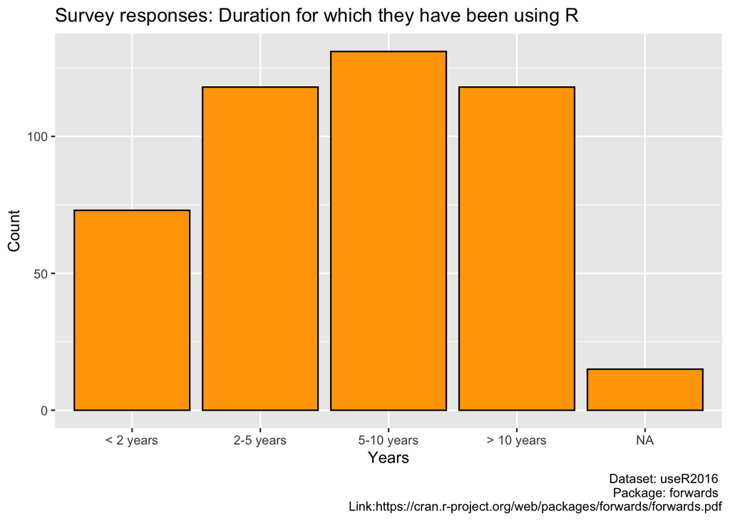

```r
q11_freq$Q11 <- factor(q11_freq$Q11, levels = c("< 2 years", "2-5 years", "5-10 years", "> 10 years", "NA"))

ggplot(q11_freq, aes(x=Q11, y=freq)) +
  geom_col(color="black", fill="orange") +
  labs(x="Years", y="Count", title="Survey responses: Duration for which they have been using R",
       caption="Dataset: useR2016 \n Package: forwards \n Link:https://cran.r-project.org/web/packages/forwards/forwards.pdf")
```

3. Create a horizontal stacked bar chart showing the proportion of respondents for each level of Q11 who are over 35 vs. 35 or under. Use a descriptive title.

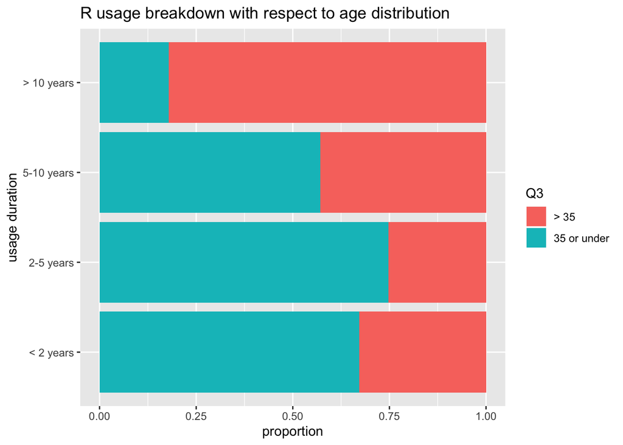

```r
q11_stack <- data[, c("Q11", "Q3")] %>%
  na.omit() %>%
  group_by(Q11, Q3) %>%
  count(Q11)


ggplot(q11_stack, aes(fill=Q3, y=n, x=Q11)) +
  geom_bar(position = "fill", stat = "identity") +
  xlab("usage duration") +
  ylab("proportion")+
  coord_flip()+
  ggtitle("R usage breakdown with respect to age distribution")
```